# Week3.HW.041819

Rie

4/18/2019

```r
library(rethinking)
p_grid <- seq(from=0, to=1, length.out = 1000)
prob_p <- rep(1,1000)
prob_data <- dbinom(6, size = 9, prob = p_grid)
posterior <- prob_data*prob_p
posterior <- posterior / sum(posterior)
samples <- sample( p_grid , prob=posterior , size=1e4 , replace=TRUE )
```

### 3E1 How much posterior probability lies below p = 0.2?

```r
sum( samples <0.2)/1e4
```

```
## [1] 0.001
```

### 3E2 How much posterior probability lies above p = 0.8?

```r
sum( samples > 0.8)/1e4
```

```
## [1] 0.1241
```

### 3E3 How much posterior probability lies between p = 0:2 and p = 0:8?

```r
sum( samples > 0.2 & samples <0.8)/1e4
```

```
## [1] 0.8749
```

### 3E4 20% of the posterior probability lies below which value of p?

```r
quantile(samples, 0.2)
```

```
##       20%
## 0.5185185
```

### 3E5 20% of the posterior probability lies above which value of p?

```r
quantile(samples, c(0.2, 1))
```

```
##       20%      100%
## 0.5185185 0.9849850
```

### 3E6 Which values of p contain the narrowest interval equal to 66% of the posterior probability?

```r
HPDI(samples, prob = 0.66)
```

```
##     |0.66     0.66|
## 0.5055055 0.7767768
```

### 3E7 Which values of p contain 66% of the posterior probability, assuming equal posterior probability both below and above the interval?

```r
PI(samples, prob = 0.66)
```

```
##       17%       83%
## 0.5015015 0.7747748
```

### 3M1 Suppose the globe tossing data had turned out to be 8 water in 15 tosses. Construct the posterior distribution, using grid approximation. Use the same flat prior as before.

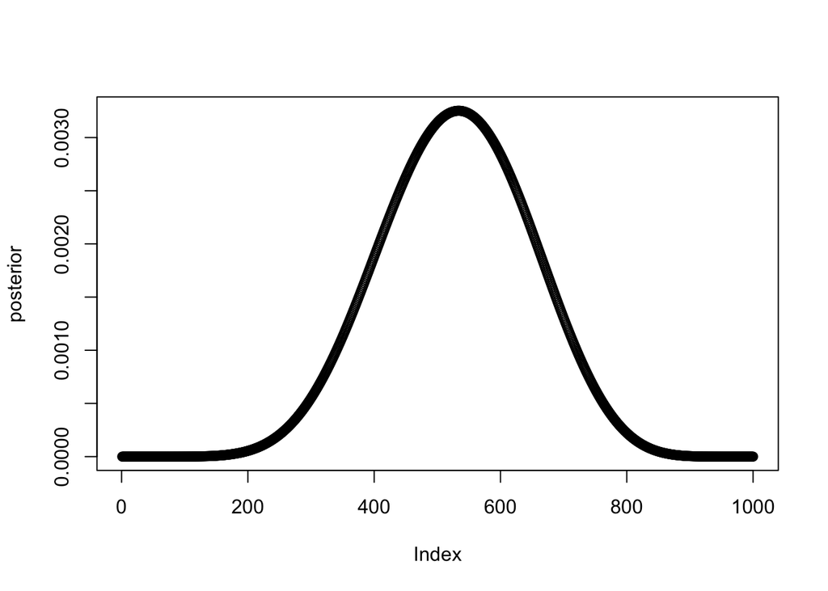

```r
p_grid <- seq(from=0, to=1, length.out = 1000)
prob_p <- rep(1,1000)
prob_data <- dbinom(8, size = 15, prob = p_grid)
posterior <- prob_data*prob_p
posterior <- posterior / sum(posterior)
plot(posterior)
```

###3M2 Draw 10,000 samples from the grid approximation from above. Then use the samples to calculate the 90% HPDI for p.

```r
samples <- sample(p_grid, size = 1e4, replace = T)
HPDI(samples, prob=0.9)
```

```
##      |0.9      0.9|
## 0.1071071 0.9989990
```

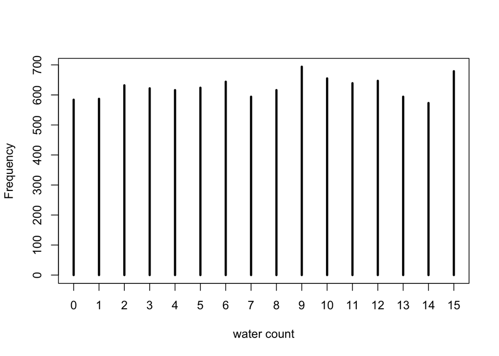

```r
w <- rbinom(1e4, size = 15, prob = samples)
simplehist(w, xlab = "water count")
```

###3M4 Using the posterior distribution constructed from the new (8/15) data, now calculate the probability of observing 6 water in 9 tosses.

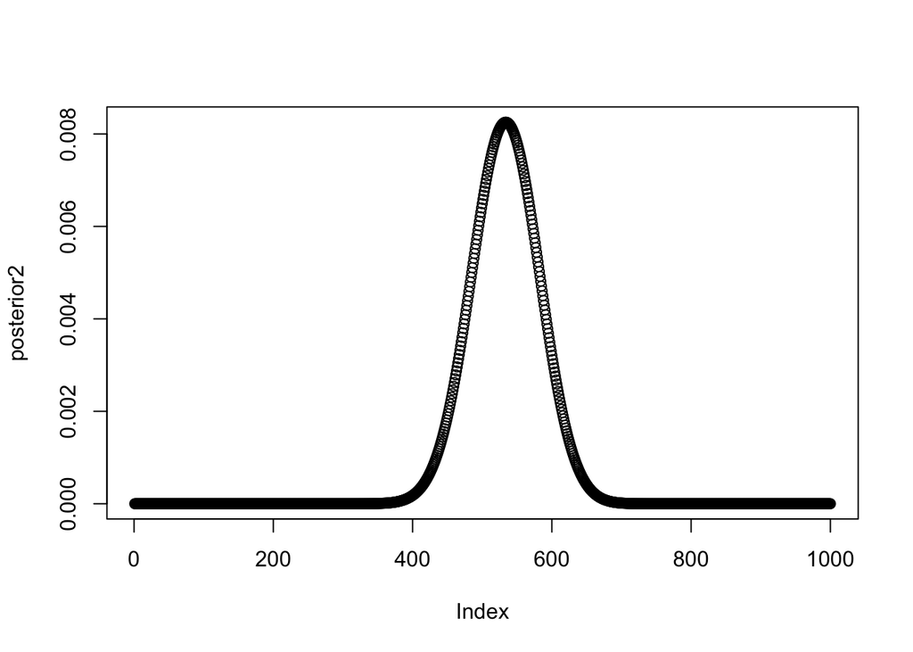

```r
prob_data2 <- dbinom(6, size = 9, prob = posterior)
posterior2 <- prob_data2*posterior
posterior2 <- posterior2 / sum(posterior2)
plot(posterior2)
```

```r
p_grid <- seq(from=0, to=1, length.out = 1000)
prob_p <- rep(0,1000)
prob_data <- dbinom(8, size = 15, prob = p_grid)
posterior <- prob_data*prob_p
posterior <- posterior / sum(posterior)


samples <- sample(p_grid, size = 1e4, replace = T)
HPDI(samples, prob=0.5)
```

```
##      |0.5      0.5|
## 0.2802803 0.7697698
```

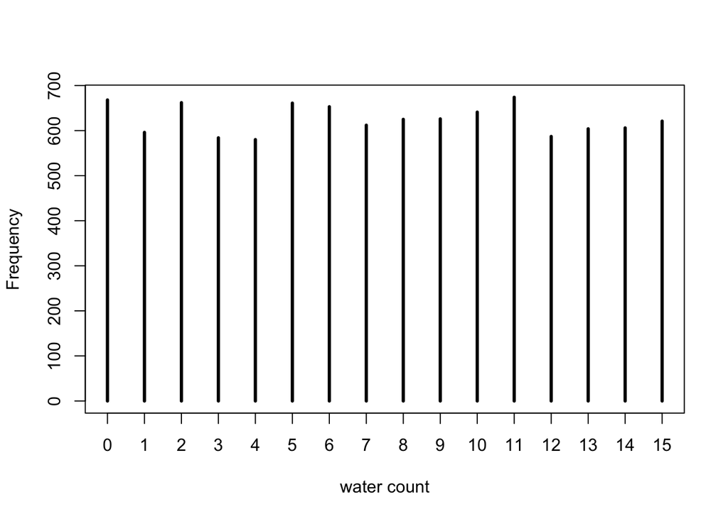

```r
w <- rbinom(1e4, size = 15, prob = samples)
simplehist(w, xlab = "water count")
```

```r
prob_data2 <- dbinom(6, size = 9, prob = posterior)
posterior2 <- prob_data2*posterior
posterior2 <- posterior2 / sum(posterior2)
```

```r
p_grid <- seq(from=0, to=1, length.out = 1000)
prob_p <- rep(0,1000)
prob_data <- dbinom(8, size = 15, prob = p_grid)
posterior <- prob_data*prob_p
posterior <- posterior / sum(posterior)


samples <- sample(p_grid, size = 1e4, replace = T)
HPDI(samples, prob=0.7)
```

```
##      |0.7      0.7|
## 0.1801802 0.8728729
```

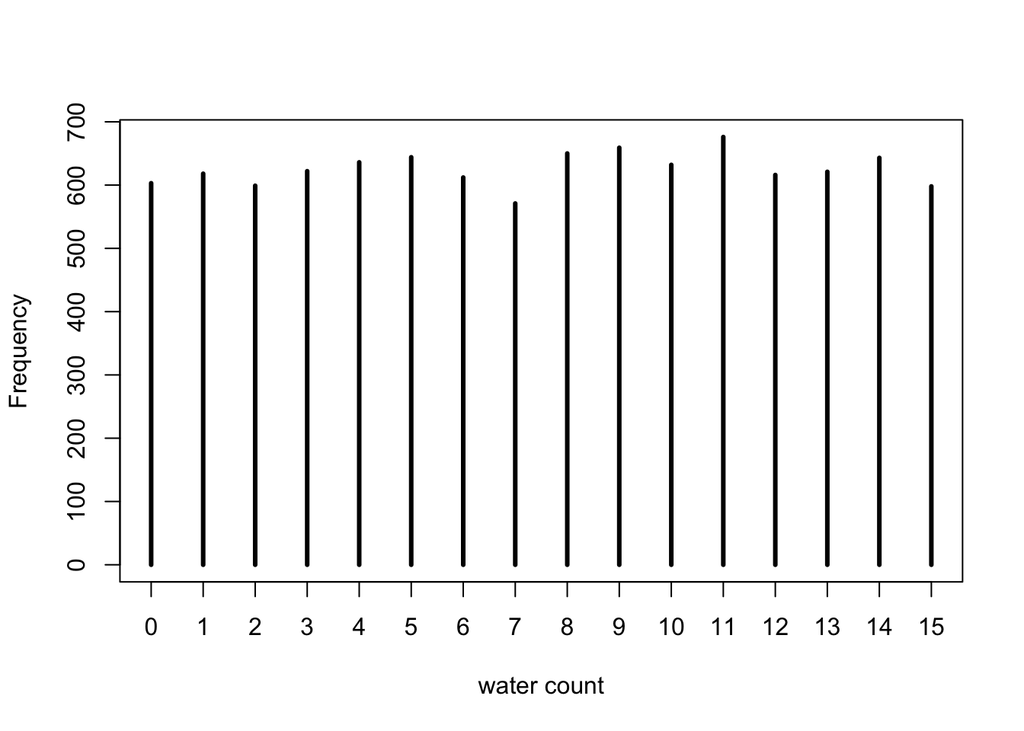

```r
w <- rbinom(1e4, size = 15, prob = samples)
simplehist(w, xlab = "water count")
```

```r
prob_data2 <- dbinom(6, size = 9, prob = posterior)
posterior2 <- prob_data2*posterior
posterior2 <- posterior2 / sum(posterior2)
```